# EDEN modelling of Tasmanian rocky reefs

MP Marzloff

2025-02-26

## Analysing possible socio-ecosystem trajectories of shifts from dense productive kelp beds to sea urchin barrens (and back)

Using the EDEN framework and unfolding algorithm, this document aims at summarising all potential trajectories of regime shifts on Tasmanian rocky reefs.

## IMPORT PACKAGES

```r
library(ggplot2)
library(vegan)
library(ggrepel)
```

## Import results from the unfolding and information about model rules

Three files are used to produce these outputs: 1) a first one that lists the 26 ‘configurations’, i.e. alternative suites of model rules required to go from a macroalgal bed to a sea urchin barren state; 2) a second one that lists the 46 ‘configurations’, i.e. alternative suites of model rules required to go from a sea urchin barren, to a macroalgal bed state; 3) a third one that summarises the meaning of each of the 22 model rules, and how they can be categorised into 4 groups: (i) ‘ecological’ or (ii) ‘climate-driven’ processes, (iii) harvesting by fishing of commercial population (i.e. rock lobster or abalone), (iv) management interentions (which restricts fishing activity, or actively restore valuable populations, or directly control, for instance using culling, barren-forming sea urchin populations)

```r
unfolding_dir <- "/Users/mpmarzlo/Documents/Students/AGUIRRE-SAMBONI_GiannKarlo/Results/202501_Paper/3_PCA"
setwd(unfolding_dir)

alg2barren <- readLines("minconfs-to-marking_tasmanian_perturb_final_pr_alg2urc.rules")
barren2alg <- readLines("minconfs-to-marking_tasmanian_perturb_final_pr_urc2alg.rules")
modelRules <- read.csv("ModelRules.csv", header = T)

## Colour codes
col_scheme = c("ecological" = "#1a9850", "climate-change"= "#d73027","over-exploitation" = "#fee08b","interventions" = "#8c510a")
```

## Function for graphical PCA outputs

This chunk of code defines all the functions used to perform Principal Components Analyses (PCAs) and to generate the different visual outputs.

```r
performPCA <- function(mat_pca){

  pca <- prcomp(t(mat_pca))

  # SUMMARY PCA
  var_expl <- pca$sd^2
  var_expl <- round(var_expl / sum(var_expl)*100 , digits = 1)
  barplot(var_expl, ylab = '% Variance explained', names.arg = paste0("PC",seq(1,length(var_expl))), cex.names = .6)

  # Prepare data.frame 'dfForPCA' #
  dfForPCA <- data.frame(PC1 = pca$x[,1], PC2 = pca$x[,2], Instance = as.factor(seq(1:ncol(mat_pca))))

  # Prepare projections of variables onto PC1 and PC2 #
  df_vecPCA <- data.frame(x = pca$rotation[,1],
                          y = pca$rotation[,2], z = pca$rotation[,3])
  df_vecPCA$normPC12 <- sqrt(df_vecPCA$x^2 + df_vecPCA$y^2)

  # Plot unfolding instances (i.e. trajectories) scores on PC1 and PC2
p1 <- ggplot(data = dfForPCA, aes(x= PC1, y= PC2, colour = Instance, label = Instance)) +
  geom_point(size=6, col = "darkblue") +   # geom_text(colour = "darkgrey", position = position_jitter(width = 0.05, height= 0.1))+
  geom_text_repel()+
  theme(text = element_text(size=15), legend.position = "none")+ #, legend.key.size = unit(1.1,'cm'))+
  labs(x = paste('PC 1 (', var_expl[1],'% of total variance)' ),
       y = paste('PC 2 (', var_expl[2],'% of total variance)' ))
#print(p1)

# Plot projections of model rules onto PC1 and PC2 #
set.seed(123)
p2 <- ggplot(data = df_vecPCA[df_vecPCA$normPC12>0.3,], aes(x=x, y= y, xend= 0, yend= 0, label = rownames(df_vecPCA)[df_vecPCA$normPC12>0.3])) + ## could add some colour code for the types of rules
  geom_text(colour = "black",nudge_x=.05, nudge_y =.1)+ # position = position_jitter(width = 0.05, height= 0.1))+
  geom_segment(aes(x = 0, y = 0, xend = x, yend = y), arrow = arrow(length=unit(0.30,"cm"), type = "closed" ))+
  theme(text = element_text(size=15))+ #, legend.key.size = unit(1.1,'cm'))+
  labs(x = paste('PC 1 (', var_expl[1],'% of total variance)' ),
       y = paste('PC 2 (', var_expl[2],'% of total variance)' ))
#print(p2)


return( list(p1, p2) )
}

biplot_pca <- function(mat_pca){
    pca <- prcomp(t(mat_pca))
    print(biplot(pca, col = c("white", "darkblue"), var.axes = T, scale = 0))
}

plot_matrix1 <- function(mat_rules){

  p <- ggplot(data = mat_rules, aes(x = TrajectoryNumber, y = RuleNumber))+
    geom_point(aes(size = RuleCountFactor, fill = Category), shape = 21, color = "black")+
  xlab("Trajectories")+ylab("Model rules")+
  ggtitle("Rules contribution to individual trajectories")+
  theme(
    plot.title = element_text(color="black", size=14, face="italic"),
    axis.title.x = element_text(color="black", size=14, face="bold"),
    axis.title.y = element_text(color="black", size=14, face="bold"),
    plot.margin=unit(c(1,1,1,1.5),"cm") )+
    scale_size_manual(name = "Number of Rules Used",
                      labels = c("0", "1", "2+"),
                      values = c(0, 2.5, 3)) +
    scale_shape_manual(name = "Number of Rules Used",
                     labels = c("0", "1", "2+"),
                     values = c(21, 21, 21))+
    scale_fill_manual(name = "Rule Category",
                     labels = c("Climate Change", "Ecological Processes","Management intervention", "Overharvesting"),
                      values =  c("#d73027","#1a9850","#8c510a","#fee08b"))
  p
}

plot_matrix2 <- function(mat_rules){

  p <- ggplot(data = mat_rules, aes(x = TrajectoryNumber, y = RuleFull))+
    geom_point(aes(size = RuleCountFactor, fill = Category), shape = 21, color = "black")+
  xlab("Trajectories")+ylab("Model rules")+
  ggtitle("Rules contribution to individual trajectories")+
  theme(
    plot.title = element_text(color="black", size=14, face="italic"),
    axis.title.x = element_text(color="black", size=14, face="bold"),
    axis.title.y = element_text(color="black", size=14, face="bold"),
    plot.margin=unit(c(1,1,1,1.5),"cm") )+
    scale_size_manual(name = "Number of Rules Used",
                      labels = c("0", "1", "2+"),
                      values = c(0, 2.5, 3)) +
    scale_shape_manual(name = "Number of Rules Used",
                     labels = c("0", "1", "2+"),
                     values = c(21, 21, 21))+
    scale_fill_manual(name = "Rule Category",
                     labels = c("Climate Change", "Ecological Processes","Management intervention", "Overharvesting"),
                      values =  c("#d73027","#1a9850","#8c510a","#fee08b"))
  p
}
```

## Format unfolding and algal bed to sea urchin barrens trajectories for PCA

This section focuses on outputs related to possible transitions from productive and diverse macralgal beds to sea urchin barrens. PCAs are performed successively on either: (1) the number of times each model rule is required within each of the 26 configurations (i.e. alternative trajectories); (2) the presence and absence of each model rule within each of the 26 configurations; or, (3) how many times each of the 4 rule categories (i.e. ‘ecological’, ‘climate’, ‘overharvesting’ or ‘management’) contribute to each of the 26 configurations.

### PCA based on counts of rules used

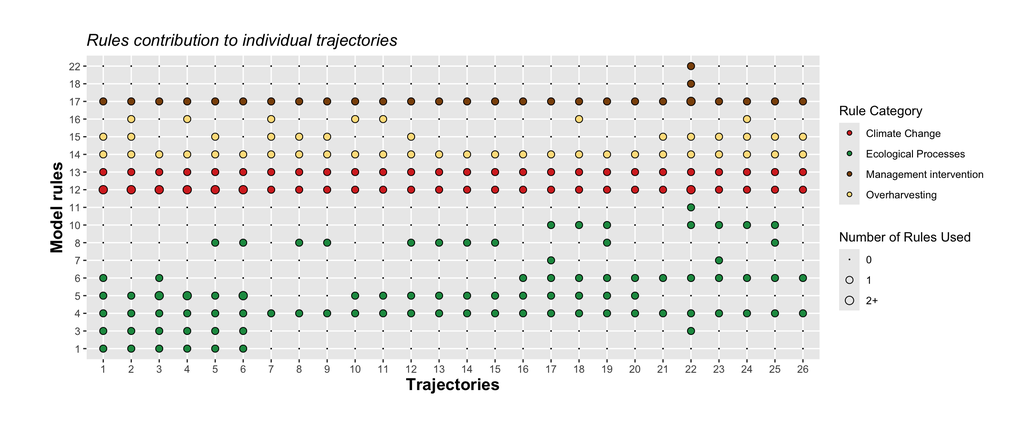

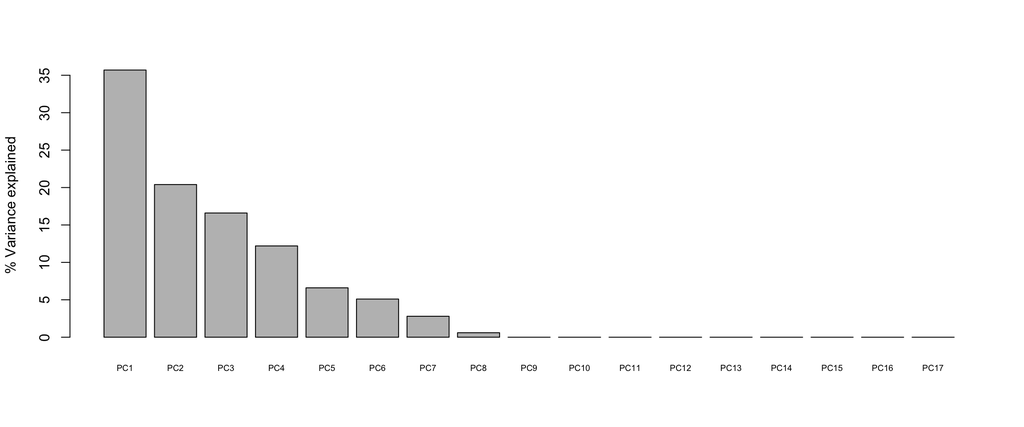

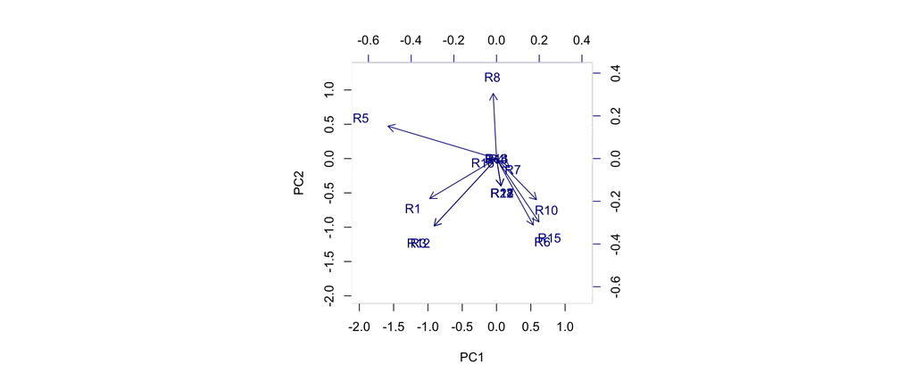

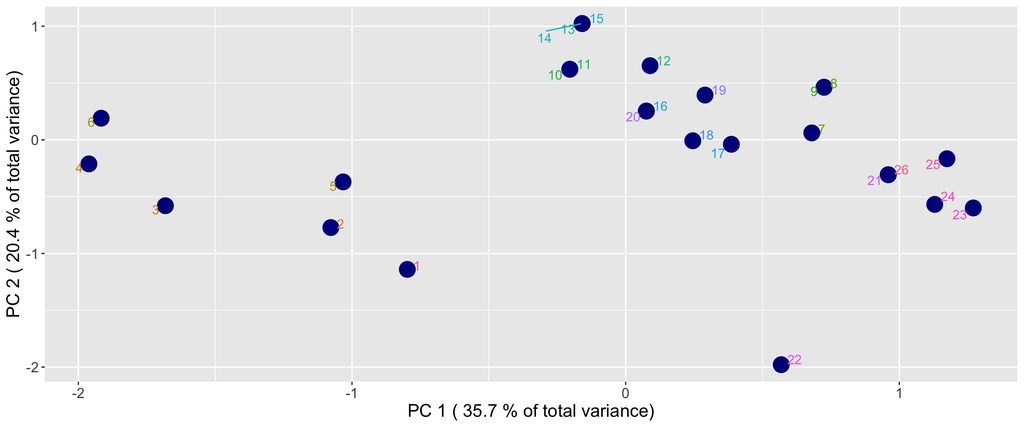

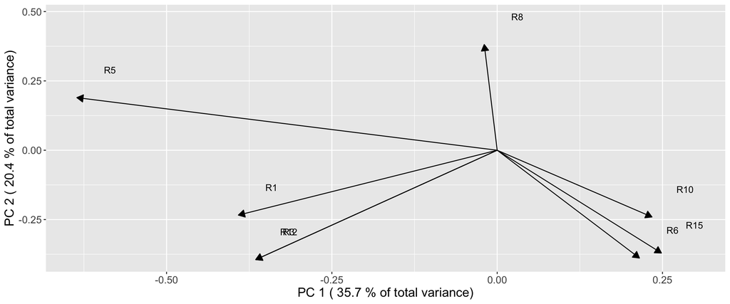

```
##    Number                      Rule
## 1       1        Alg+, Fis- >> Lob+
## 3       3              Lob+ >> Urc-
## 4       4              Urc+ >> Alg-
## 5       5              Oct+ >> Lob-
## 6       6              Lob+ >> Aba-
## 7       7              Urc+ >> Aba-
## 8       8              Oct+ >> Aba-
## 10     10        Lob-, Urc- >> Aba+
## 11     11  Alg- >> Lob-, Aba-, Oct-
## 12     12              Lob- >> Urc+
## 13     13              Oct- >> Oct+
## 14     14              Mgt- >> Fis+
## 15     15              Fis+ >> Lob-
## 16     16              Fis+ >> Aba-
## 17     17        Aba-, Lob- >> Mgt+
## 18     18        Aba+, Lob+ >> Mgt-
## 22     22              Mgt+ >> Lob+
```

### PCA based on presence of rules used

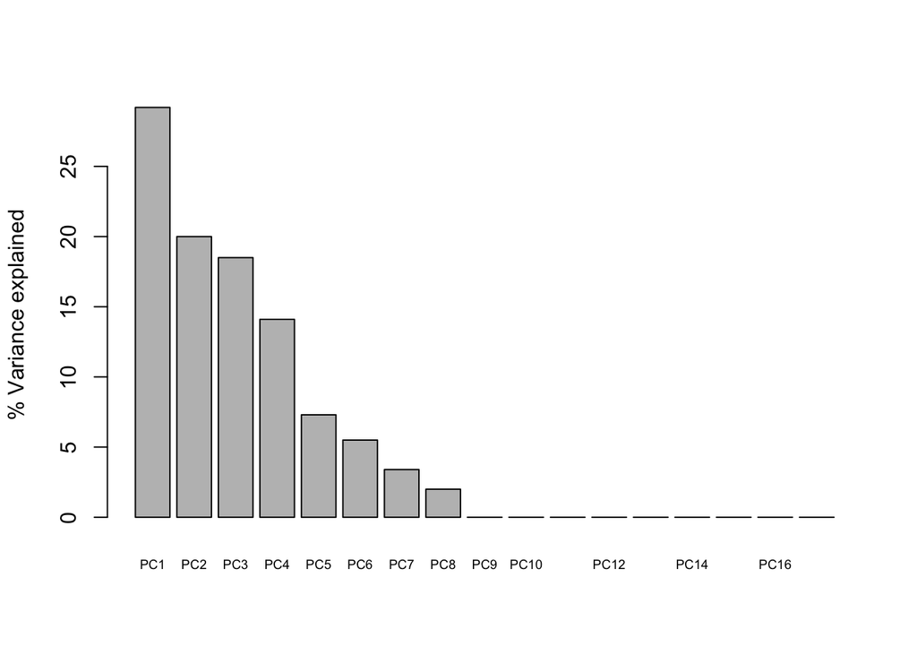

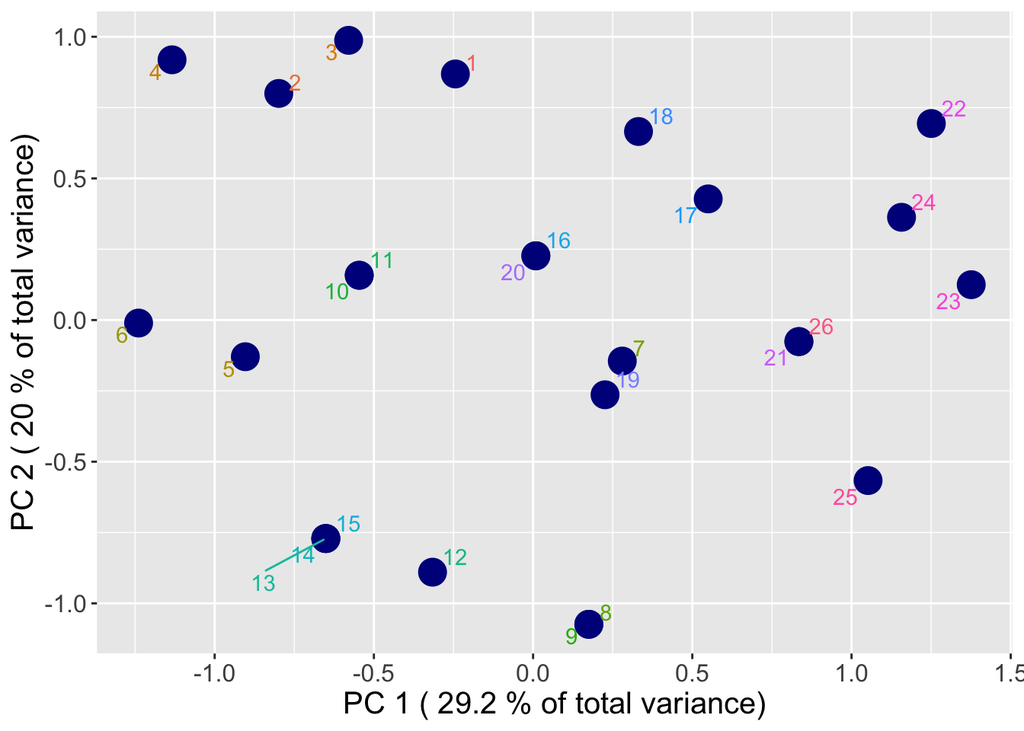

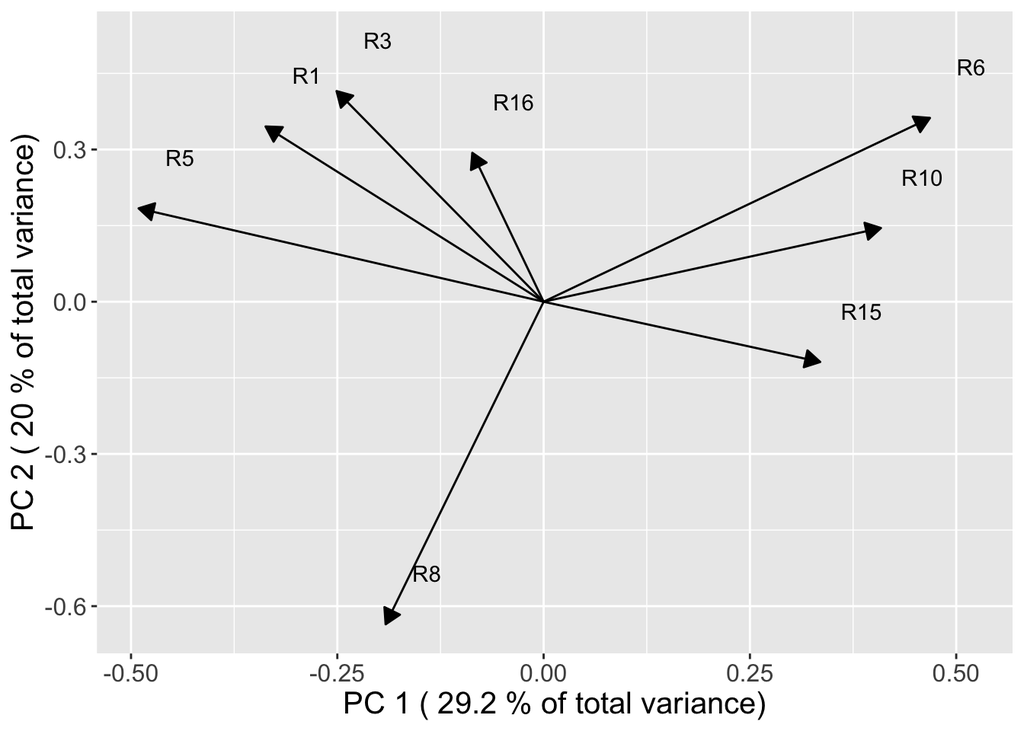

### PCA based on number of rules used within each of the four categories

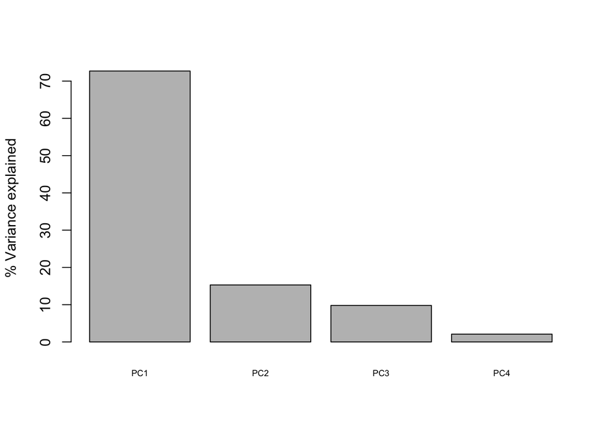

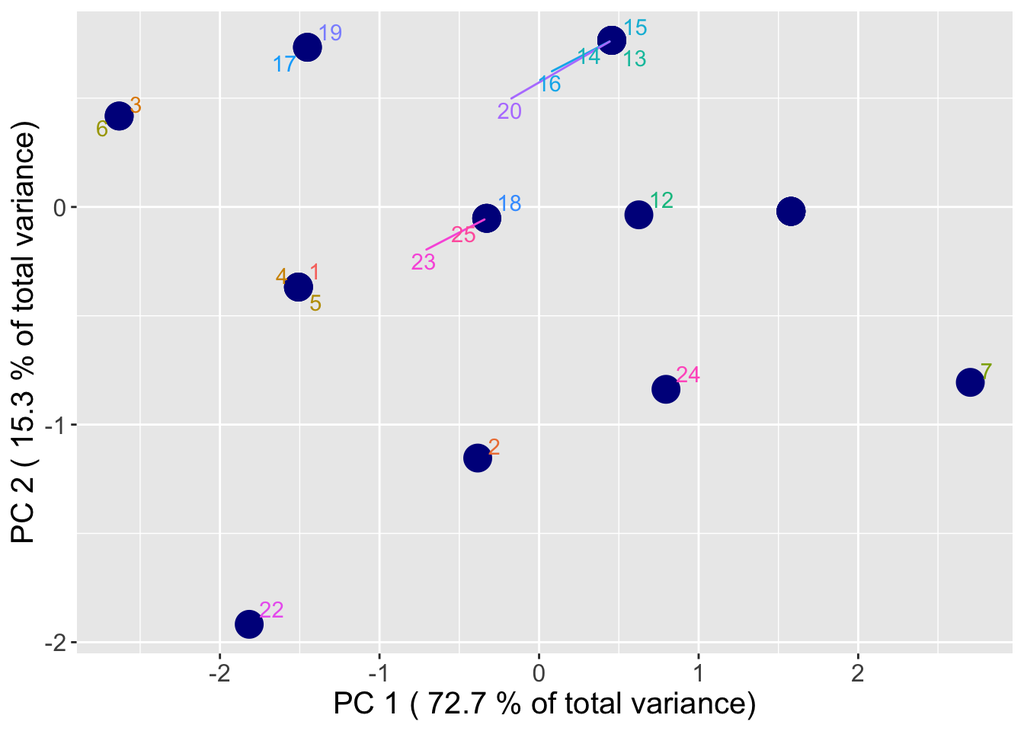

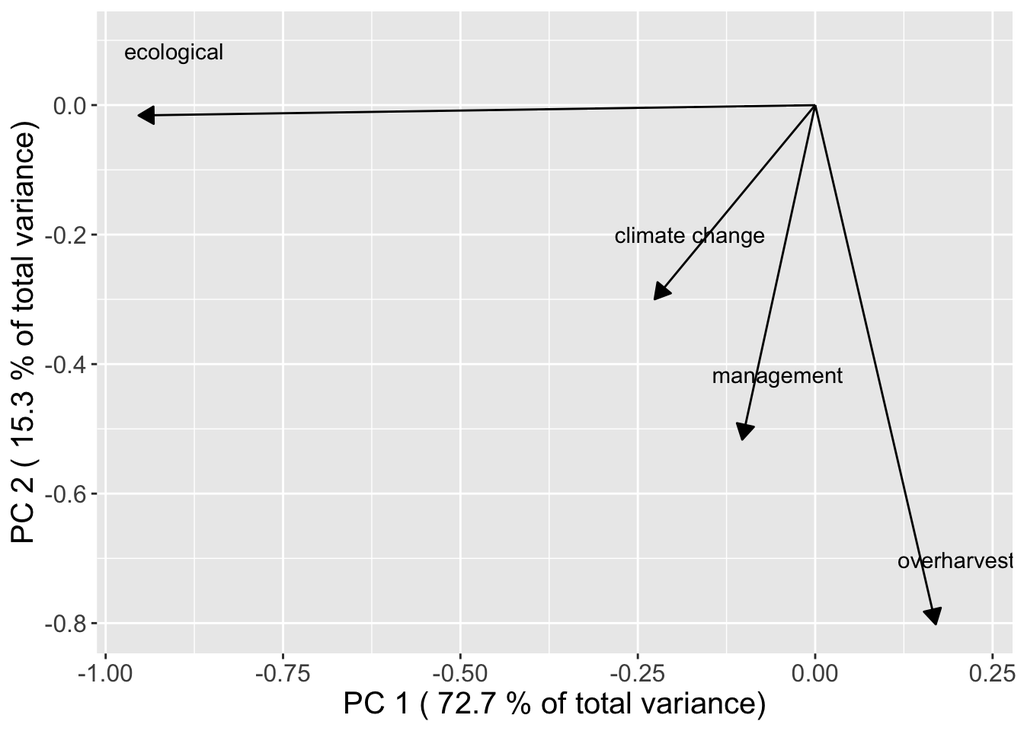

## Format unfolding and trajectories to restore algal beds from sea urchin barrens for PCA

This section focuses on outputs related to possible transitions from sea urchin barrens back to restoring productive and diverse macralgal beds. PCAs are performed successively on either: (1) the number of times each of the 22 model rules is required within each of the 46 configurations (i.e. alternative trajectories); (2) the presence and absence of each of the 22 model rules within each of the 46 configurations; or, (3) how many times each of the 4 rule categories (i.e. ‘ecological’, ‘climate’, ‘overharvesting’ or ‘management’) contribute to each of the 46 configurations.

### PCA based on total counts of rules used in each trajectory

```
##  [1] "R22 R3 R9"                         "R21 R9 R12 R22 R3"
##  [3] "R21 R9 R12 R22 R21"                "R21 R22 R9"
##  [5] "R22 R3 R11 R22 R9"                 "R21 R9 R10 R22"
##  [7] "R21 R9 R10 R12 R22 R3"             "R21 R9 R10 R12 R22 R21"
##  [9] "R11 R22 R3 R9"                     "R11 R19 R21 R22 R9"
## [11] "R11 R19 R21 R9 R10 R22"            "R11 R19 R22 R3 R9"
## [13] "R19 R21 R9 R22"                    "R19 R21 R9 R10 R22"
## [15] "R19 R21 R9 R1"                     "R19 R21 R9 R12 R1 R21"
## [17] "R19 R21 R9 R10 R1"                 "R19 R21 R9 R10 R12 R1 R21"
## [19] "R11 R19 R21 R9 R10 R12 R22 R21"    "R11 R19 R21 R9 R12 R22 R21"
## [21] "R11 R21 R9 R10 R22"                "R11 R21 R22 R9"
## [23] "R11 R21 R9 R10 R12 R22 R21"        "R11 R21 R9 R12 R22 R21"
## [25] "R11 R19 R21 R9 R1"                 "R11 R19 R21 R9 R10 R1"
## [27] "R19 R21 R9 R10 R12 R22 R21"        "R19 R21 R9 R12 R22 R21"
## [29] "R11 R21 R9 R10 R12 R22 R3"         "R11 R21 R9 R12 R22 R3"
## [31] "R11 R19 R21 R9 R12 R1 R3"          "R11 R19 R21 R9 R12 R1 R21"
## [33] "R11 R19 R21 R9 R10 R12 R1 R3"      "R11 R19 R21 R9 R10 R12 R1 R21"
## [35] "R19 R21 R10 R22 R18 R11 R9 R10 R1" "R19 R21 R10 R22 R18 R11 R9 R1"
## [37] "R19 R21 R9 R10 R12 R21 R1"         "R19 R21 R9 R12 R21 R1"
## [39] "R19 R21 R9 R10 R1"                 "R19 R21 R9 R1"
## [41] "R19 R21 R9 R10 R12 R1 R3"          "R19 R21 R9 R12 R1 R3"
## [43] "R11 R19 R21 R9 R10 R12 R21 R1"     "R11 R19 R21 R9 R10 R1"
## [45] "R11 R19 R21 R9 R12 R21 R1"         "R11 R19 R21 R9 R1"
```

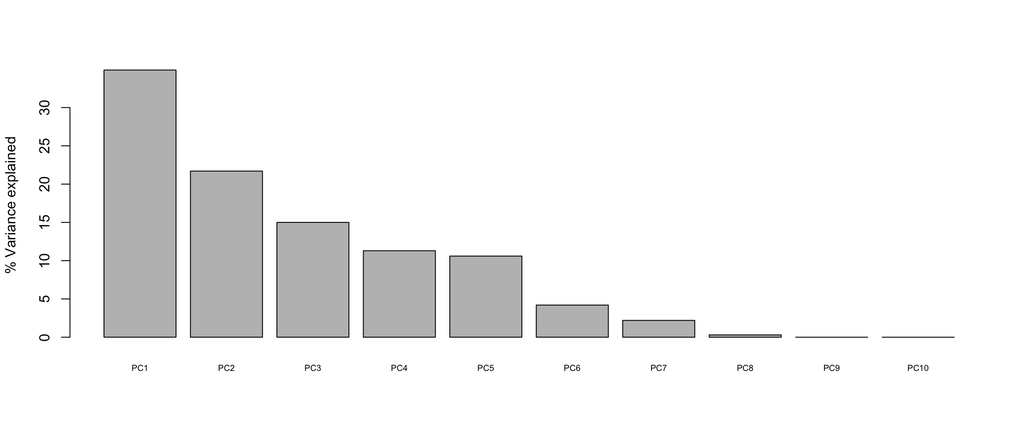

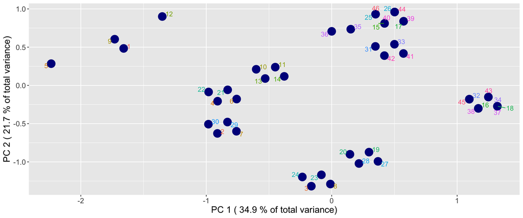

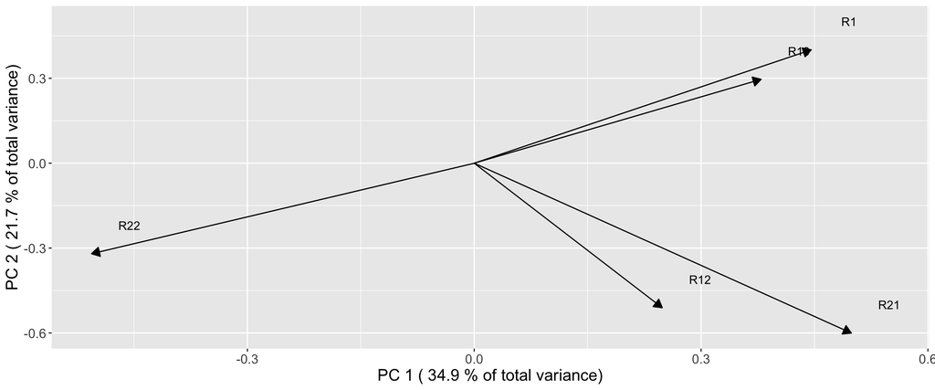

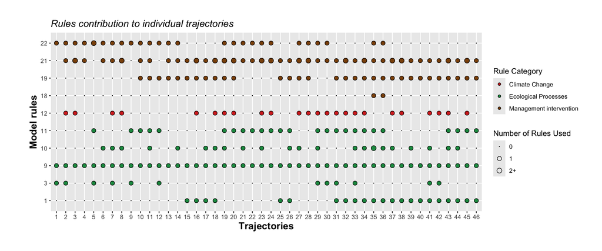

```
##    Number                      Rule
## 1       1        Alg+, Fis- >> Lob+
## 3       3              Lob+ >> Urc-
## 9       9              Urc- >> Alg+
## 10     10        Lob-, Urc- >> Aba+
## 11     11  Alg- >> Lob-, Aba-, Oct-
## 12     12              Lob- >> Urc+
## 18     18        Aba+, Lob+ >> Mgt-
## 19     19              Mgt+ >> Fis-
## 21     21              Mgt+ >> Urc-
## 22     22              Mgt+ >> Lob+
```

### PCA based on presence of rules used

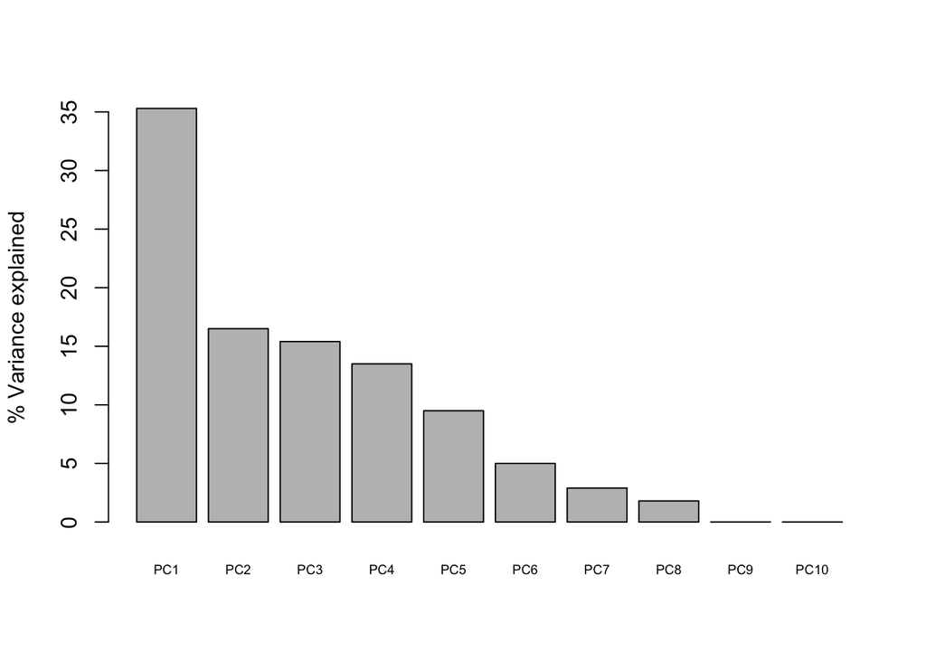

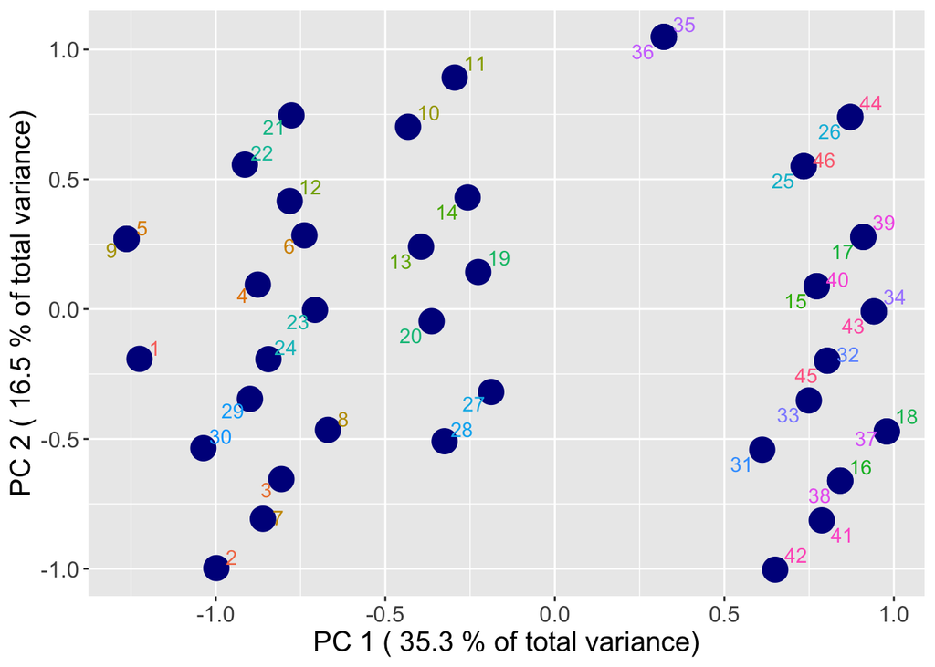

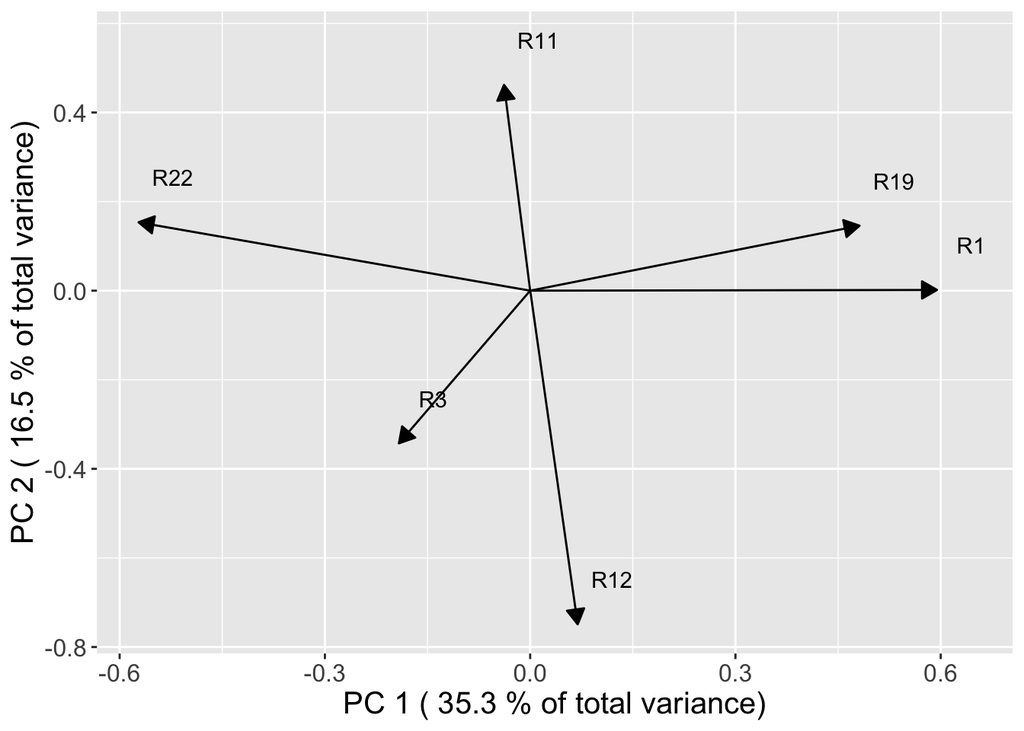

### PCA based on number of rules used within each of the four categories

```
## [1] "there is no overharvesting-related rules in recovery trajectories!!!!"
```

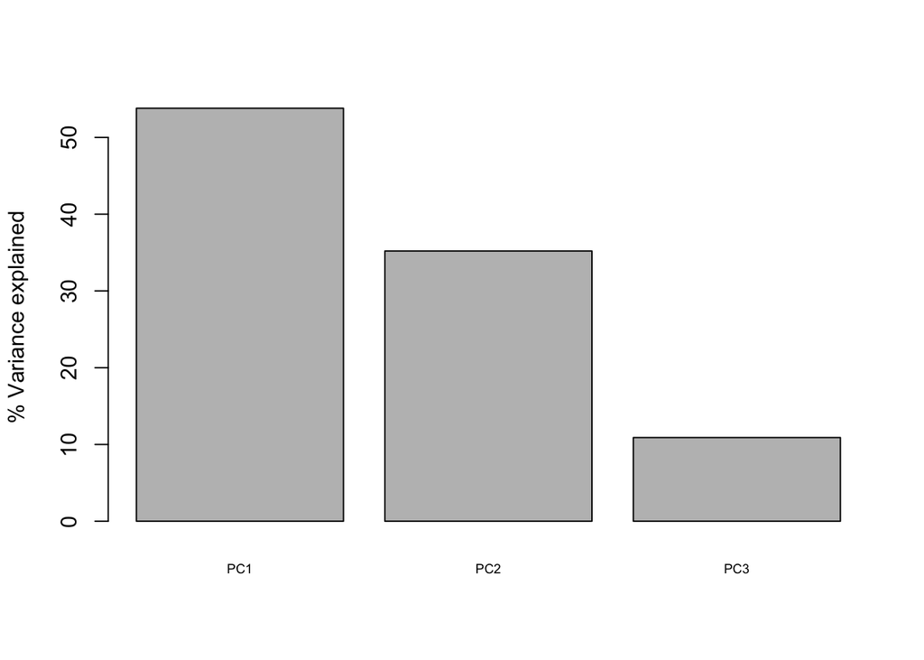

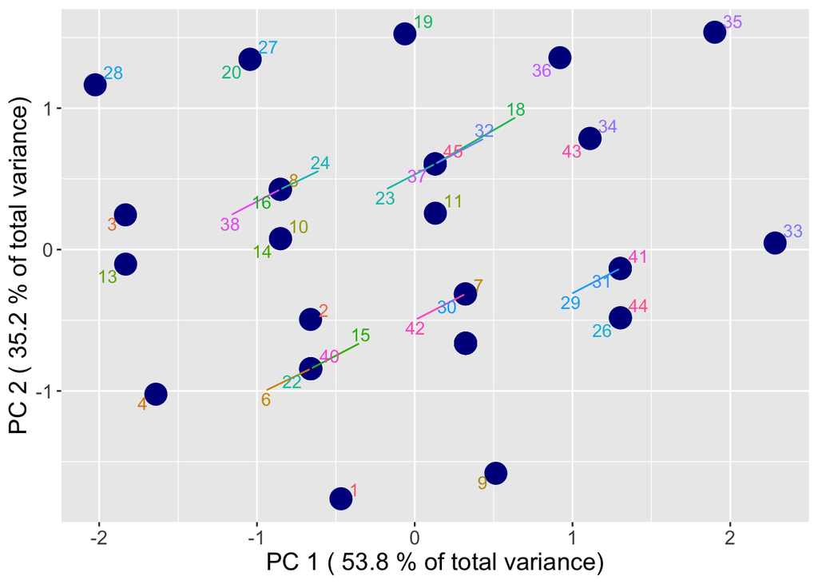

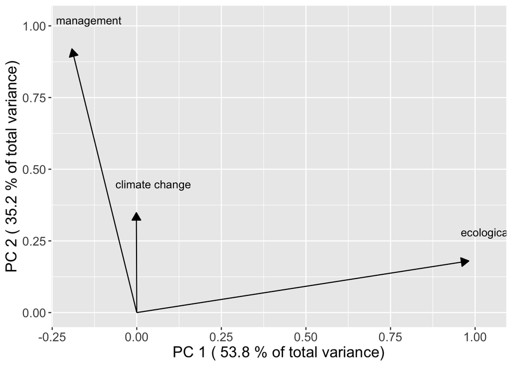